# Flexible Damage Functions

Author

James Rising, Sebastian Cadavid Sanchez, Climate Impact Lab

Published

April 30, 2026

## 0.1 Labor: Combined Country

Flexible damage function parameters at the Country level.

**Outcome units:** `portion` — dimensionless fraction of labor productivity for combined workers, rebased to 2005 baseline; population-weighted aggregation to country

$$D_{it} = (\alpha_i T_t + \beta_i T_t^2) \cdot Y_{it}^{\gamma}$$

where $\gamma$ is the income elasticity (fitted globally), $\alpha_i$ is the linear coefficient, and $\beta_i$ is the quadratic coefficient.

# 1 Global Estimation

## 1.1 Income Elasticity Estimation

The income elasticity $\gamma$ is estimated using a fixed-effects regression:

$$y_{it} = \gamma \cdot \log(Y_{it}) + \mu_{g(i,T)} + \nu_t + \varepsilon_{it}$$

where $\mu_{g(i,T)}$ are region-by-temperature-bin fixed effects and $\nu_t$ are year fixed effects.

Table 1: Income Elasticity (Gamma) Estimation Results

| Statistic | Value |
| --- | --- |
| Income elasticity ($\gamma$) | 0.4009 |
| Standard error | 3.33e-02 |
| 95% CI | [0.3357, 0.4661] |
| R-squared | 0.7188 |
| Observations | 79,181,551 |
| Regions | 245 |
| Gamma quantiles | 19 |

# 2 Parameter Distributions

## 2.1 8-Panel Summary

Row 1: gamma, alpha, beta, rsqr1. Row 2: rho, zeta, eta, rsqr2.

```
Using median gamma: 0.400896, 245 rows (of 4,655 total)
```

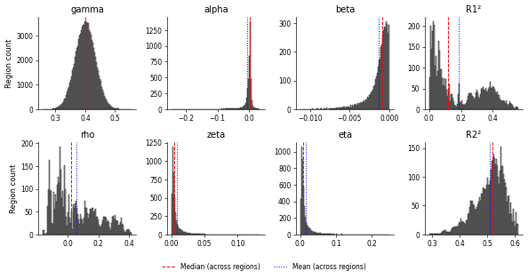

Figure 1: Distribution of Regional Parameters

## 2.2 Projection Equation and Parameter Definitions

The estimated parameters are used to project damages via Monte Carlo sampling:

$$D_{it}^k = (\hat{\alpha}_{ik} T_t + \hat{\beta}_{ik} T_t^2) Y_{it}^{\hat{\gamma}_k} + \hat{\theta}_{ik} T_t Y_{it}^{\hat{\gamma}_k} + \hat{\phi}_{it}^k$$

where $k$ indexes the Monte Carlo draw. The parameters in each row of the output CSV control distinct components of this equation:

- **gamma**: income elasticity $\hat{\gamma}_k$, one of 19 quantile values drawn from $N(\hat{\gamma}, SE(\hat{\gamma}))$
- **alpha, beta**: linear and quadratic temperature coefficients; $\hat{\alpha}_{ik}$ and $\hat{\beta}_{ik}$ are drawn from the joint normal defined by the VCV below
- **sigma11, sigma12, sigma22**: variance-covariance matrix of $(\alpha, \beta)$, used for joint uncertainty sampling
- **rho**: correlation between regional and global polynomial residuals $\rho_i$, used to maintain spatial covariance across regions in Monte Carlo draws
- **zeta**: temperature-dependent error scale $\zeta_{ik}$; the run-specific error term $\hat{\theta}_{ik}$ is drawn from $N(0, \zeta_{ik})$
- **eta**: residual noise standard deviation $\eta_{ik}$; the annual noise $\hat{\phi}_{it}^k$ is drawn from $N(0, \eta_{ik})$
- **rsqr1, rsqr2**: polynomial fit quality and error model fit, respectively

## 2.3 Summary Statistics

Table 2: Regional Parameter Summary

| Parameter | Mean | Median | Std | Min | Max | N |
| --- | --- | --- | --- | --- | --- | --- |
| alpha | -0.005656 | 0.00129 | 0.02372 | -0.1543 | 0.02197 | 245 |
| beta | -0.001296 | -0.0009277 | 0.001273 | -0.006873 | 0 | 245 |
| rho | 0.05825 | 0.02234 | 0.1443 | -0.1585 | 0.407 | 245 |
| zeta | 0.00845 | 0.00413 | 0.01308 | 0.001504 | 0.1023 | 245 |
| eta | 0.01621 | 0.008339 | 0.02407 | 0.002697 | 0.1948 | 245 |
| rsqr1 | 0.1866 | 0.1213 | 0.1587 | 0.002844 | 0.5498 | 245 |
| rsqr2 | 0.5089 | 0.5186 | 0.05531 | 0.3151 | 0.6104 | 245 |

# 3 Spaghetti Curves

Regional damage function curves showing D(T) = αT + βT² for sampled regions.

[interactive chart not shown]

Figure 2: Regional Damage Functions

# 4 Zero Crossings

The zero crossing (extremum) of the parabola occurs at $T^* = -\alpha / (2\beta)$.

Table 3: Zero Crossing Statistics

| Category | Count | Percentage |
| --- | --- | --- |
| β = 0 (no crossing) | 8 | 3.3% |
| T > 20°C (beyond graph) | 1 | 0.4% |
| T < 0°C (negative crossing) | 94 | 38.4% |
| Valid crossings (0-20°C) | 142 | 58.0% |

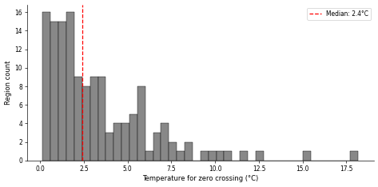

Figure 3: Distribution of Zero Crossing Temperatures

# 5 Slope Analysis

Maximum slope between 0 and 10°C: $\frac{dM}{dT} = \alpha + 2\beta T$

The maximum occurs at either T=0 or T=10 (endpoints of interval).

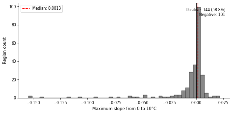

Figure 4: Distribution of Maximum Slopes (0-10°C)

*Convexity analysis omitted (beta constraint active).*

# 6 R-squared Analysis

## 6.1 Polynomial Fit Quality (rsqr1)

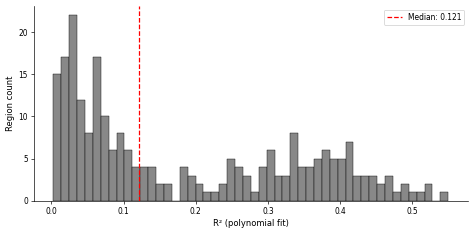

Figure 5: Regional Fit Quality (R-squared)

## 6.2 Error Model R-squared (rsqr2) Quantiles

Table 4: rsqr2 Quantiles

| 0% (Min) | 25% | 50% (Median) | 75% | 100% (Max) |
| --- | --- | --- | --- | --- |
| 0.3151 | 0.4762 | 0.5186 | 0.5495 | 0.6104 |

# 7 Modelled Variance

Modelled variance statistic: $1 - \frac{\sum_i \eta_i^2}{\sum_i D_i^2}$

Table 5: Modelled Variance Statistics

| Statistic | Value |
| --- | --- |
| Modelled variance | 0.8604 |
| Sum(η²) | 0.2058 |
| Sum(D²) at T=3.0°C | 1.4741 |
| N regions | 245 |

# 8 Best- and Worst-Fitting Regions

The 3 worst- and 3 best-fitting regions by R-squared, with raw simulation data overlaid on the fitted polynomial curve. **Red rows = worst fits**, **green rows = best fits**.

Table 6: Best- and worst-fitting regions

Top 3 best fit (R²) Top 3 worst fit (R²)

| Region | α | β | η | R² |
| --- | --- | --- | --- | --- |
| SAU | -0.0157 | -0.00178 | 0.0141 | 0.55 |
| VEN | -0.00477 | -0.00191 | 0.00883 | 0.526 |
| BHR | -0.0132 | -0.00268 | 0.0166 | 0.517 |
| URY | 0.00104 | -2.25e-4 | 0.00415 | 0.00284 |
| TWN | 3.85e-4 | -1.30e-4 | 0.0027 | 0.00457 |
| AUS | 3.08e-4 | -1.28e-4 | 0.00281 | 0.00576 |

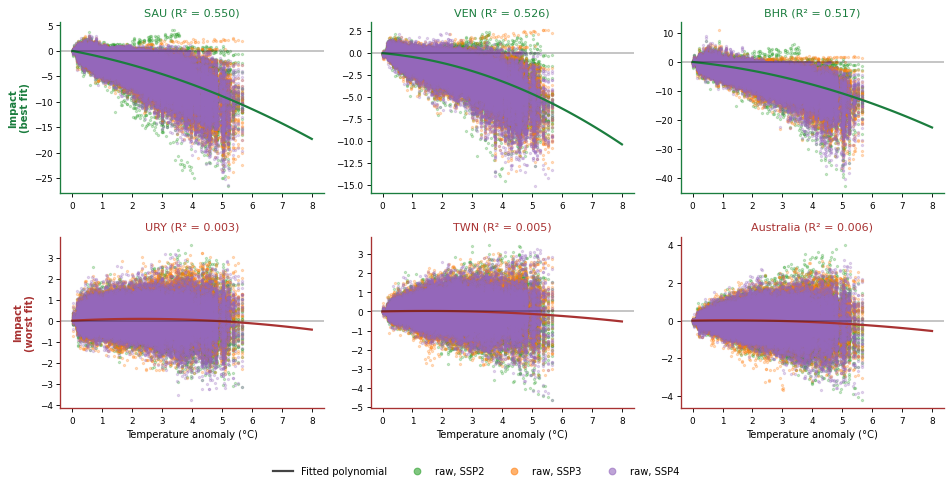

# 9 Regional Parameter Maps

Maps of key parameters at the **country** level. Red = negative (damage increases with T), Blue = positive.

## 9.1 Alpha (Linear Coefficient)

Alpha ($\alpha$) represents the linear sensitivity to temperature. Regions with negative alpha experience damage that increases with the first degree of warming.

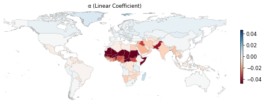

Figure 7: α (linear coefficient)

## 9.2 Beta (Quadratic Coefficient)

Beta ($\beta$) represents the curvature of the damage function.

The concavity ($\beta \leq 0$) constraint is enforced for this sector, meaning optimal temperature exists, damages accelerate beyond it.

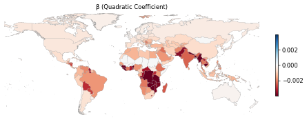

Figure 8: β (quadratic coefficient)

## 9.3 R-squared (Fit Quality)

$R^2$ measures the polynomial fit quality. Higher values indicate that the quadratic form captures more of the variance in the data.

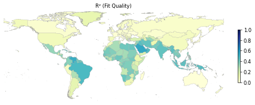

Figure 9: R² (stage 1 fit quality)

# 10 F2: Flex vs Raw Comparison

Comparison of flexible damage function predictions against raw simulation means.

For each scenario (RCP × SSP × Model), we compute at the final year:

- **Flex predicted**: $(\alpha \cdot T + \beta \cdot T^2) \cdot Y^\gamma$
- **Raw actual**: The outcome variable (y) from the source data

**Year 2099**: 1,480,050 rows

**rcp45**

**SSP2**

**high**

**Correlation:** 0.8988 | **RMSE:** 2.463873 | **Sign agreement:** 91.8%

[interactive chart not shown]

Top 5 best predicted Top 5 worst predicted

Year 2099 · T<sub>mean</sub> across these regions: 1.96°C

| Region | Raw | Flex | Residual |
| --- | --- | --- | --- |
| TWN | 0.0266 | 0.0307 | 0.00405 |
| LUX | 0.204 | 0.199 | -0.00556 |
| USA | -0.125 | -0.119 | 0.00609 |
| AUS | 0.0061 | 0.0125 | 0.00639 |
| KIR | -0.5 | -0.482 | 0.0178 |
| BFA | -4.28 | -21 | -16.7 |
| NER | -5.1 | -20.6 | -15.5 |
| TCD | -4.3 | -15.8 | -11.5 |
| MLI | -5.23 | -15.9 | -10.7 |
| SDN | -4.68 | -14.5 | -9.79 |

**low**

**Correlation:** 0.9467 | **RMSE:** 1.158254 | **Sign agreement:** 89.8%

[interactive chart not shown]

Top 5 best predicted Top 5 worst predicted

Year 2099 · T<sub>mean</sub> across these regions: 1.96°C

| Region | Raw | Flex | Residual |
| --- | --- | --- | --- |
| GEO | -0.0245 | -0.0217 | 0.00277 |
| DZA | -0.846 | -0.843 | 0.00345 |
| AGO | -0.354 | -0.349 | 0.00513 |
| TZA | -0.293 | -0.299 | -0.00549 |
| ARG | -0.205 | -0.213 | -0.00778 |
| SOM | -2.88 | -12.9 | -10.1 |
| SDN | -5.37 | -11.4 | -6.02 |
| NER | -6.58 | -12 | -5.41 |
| MLI | -6.12 | -11.5 | -5.4 |
| BFA | -6.25 | -11 | -4.74 |

**SSP3**

**high**

**Correlation:** 0.9507 | **RMSE:** 0.699294 | **Sign agreement:** 91.4%

[interactive chart not shown]

Top 5 best predicted Top 5 worst predicted

Year 2099 · T<sub>mean</sub> across these regions: 1.96°C

| Region | Raw | Flex | Residual |
| --- | --- | --- | --- |
| FJI | 0.142 | 0.144 | 0.00177 |
| BIH | 0.33 | 0.334 | 0.00373 |
| TON | 0.295 | 0.299 | 0.00445 |
| NIC | -1.26 | -1.26 | 0.00643 |
| GBR | 0.275 | 0.284 | 0.00843 |
| BFA | -6.05 | -11.2 | -5.12 |
| DJI | -3.9 | -7.83 | -3.93 |
| NER | -7.01 | -10.4 | -3.38 |
| TCD | -5.96 | -8.84 | -2.88 |
| TGO | -2.82 | -5.33 | -2.52 |

**low**

**Correlation:** 0.9676 | **RMSE:** 0.577378 | **Sign agreement:** 94.7%

[interactive chart not shown]

Top 5 best predicted Top 5 worst predicted

Year 2099 · T<sub>mean</sub> across these regions: 1.96°C

| Region | Raw | Flex | Residual |
| --- | --- | --- | --- |
| AUS | 0.011 | 0.0112 | 2.48e-4 |
| USA | -0.126 | -0.125 | 9.41e-4 |
| BGR | 0.19 | 0.191 | 9.44e-4 |
| POL | 0.453 | 0.451 | -0.00205 |
| TWN | 0.0288 | 0.0268 | -0.00206 |
| TCD | -7.44 | -4.6 | 2.83 |
| BFA | -7.92 | -5.13 | 2.79 |
| NER | -8.24 | -5.67 | 2.57 |
| MLI | -8.03 | -5.63 | 2.4 |
| MRT | -6.85 | -4.79 | 2.06 |

**SSP4**

**high**

**Correlation:** 0.9560 | **RMSE:** 0.579921 | **Sign agreement:** 91.8%

[interactive chart not shown]

Top 5 best predicted Top 5 worst predicted

Year 2099 · T<sub>mean</sub> across these regions: 1.96°C

| Region | Raw | Flex | Residual |
| --- | --- | --- | --- |
| GAB | -0.401 | -0.401 | 1.84e-4 |
| CYP | -0.613 | -0.615 | -0.00282 |
| TWN | 0.0277 | 0.0322 | 0.00447 |
| TZA | -0.288 | -0.28 | 0.00798 |
| LBN | -0.412 | -0.421 | -0.00874 |
| DJI | -3.71 | -8.07 | -4.37 |
| BFA | -6.3 | -9.41 | -3.12 |
| MRT | -5.43 | -7.91 | -2.48 |
| SOM | -4.33 | -2.2 | 2.13 |
| TCD | -5.97 | -8.05 | -2.08 |

**low**

**Correlation:** 0.9627 | **RMSE:** 0.454567 | **Sign agreement:** 90.2%

[interactive chart not shown]

Top 5 best predicted Top 5 worst predicted

Year 2099 · T<sub>mean</sub> across these regions: 1.96°C

| Region | Raw | Flex | Residual |
| --- | --- | --- | --- |
| NIU | 0.242 | 0.241 | -0.00104 |
| CXR | 0.305 | 0.308 | 0.00301 |
| LVA | 0.599 | 0.596 | -0.00342 |
| BHS | -0.443 | -0.448 | -0.0051 |
| RUS | 0.481 | 0.47 | -0.0116 |
| SOM | -3.51 | -8.22 | -4.71 |
| MMR | -2.82 | -1.18 | 1.64 |
| ERI | -1.83 | -3.34 | -1.51 |
| KWT | -4.44 | -3.07 | 1.38 |
| BFA | -7.59 | -6.38 | 1.21 |

**rcp85**

**SSP2**

**high**

**Correlation:** 0.9172 | **RMSE:** 4.408662 | **Sign agreement:** 86.5%

[interactive chart not shown]

Top 5 best predicted Top 5 worst predicted

Year 2099 · T<sub>mean</sub> across these regions: 4.20°C

| Region | Raw | Flex | Residual |
| --- | --- | --- | --- |
| BDI | -1.41 | -1.42 | -0.00832 |
| ISR | -2.02 | -2.03 | -0.0111 |
| DZA | -3.26 | -3.29 | -0.0247 |
| PLW | -2.71 | -2.74 | -0.0295 |
| ARG | -1.1 | -1.06 | 0.0392 |
| BFA | -15.4 | -45 | -29.6 |
| NER | -17.2 | -44.2 | -27 |
| TCD | -14.6 | -34 | -19.4 |
| TGO | -8.25 | -25.5 | -17.2 |
| MLI | -17.5 | -34.3 | -16.7 |

**low**

**Correlation:** 0.9564 | **RMSE:** 1.608893 | **Sign agreement:** 88.2%

[interactive chart not shown]

Top 5 best predicted Top 5 worst predicted

Year 2099 · T<sub>mean</sub> across these regions: 4.20°C

| Region | Raw | Flex | Residual |
| --- | --- | --- | --- |
| LAO | -4.75 | -4.75 | 8.94e-4 |
| BHS | -1.55 | -1.57 | -0.0205 |
| SYR | -6 | -6.02 | -0.021 |
| HND | -2.5 | -2.52 | -0.0232 |
| EST | 0.998 | 1.02 | 0.0238 |
| SOM | -9.33 | -27.8 | -18.5 |
| SDN | -18.2 | -24.5 | -6.26 |
| MLI | -19.9 | -24.7 | -4.84 |
| NER | -21.3 | -25.7 | -4.43 |
| MMR | -6.03 | -10.1 | -4.05 |

**SSP3**

**high**

**Correlation:** 0.9670 | **RMSE:** 1.281381 | **Sign agreement:** 93.1%

[interactive chart not shown]

Top 5 best predicted Top 5 worst predicted

Year 2099 · T<sub>mean</sub> across these regions: 4.20°C

| Region | Raw | Flex | Residual |
| --- | --- | --- | --- |
| CCK | 0.642 | 0.646 | 0.00379 |
| ALA | 1.58 | 1.58 | 0.00403 |
| ETH | -2.07 | -2.06 | 0.00802 |
| DNK | 0.716 | 0.729 | 0.0127 |
| IMN | 1.06 | 1.08 | 0.0131 |
| IRQ | -15.2 | -8.53 | 6.66 |
| SOM | -12.9 | -8.04 | 4.87 |
| BHR | -12.8 | -8.3 | 4.55 |
| BFA | -19.6 | -24 | -4.35 |
| IND | -8.28 | -4.4 | 3.88 |

**low**

**Correlation:** 0.9572 | **RMSE:** 3.089205 | **Sign agreement:** 91.0%

[interactive chart not shown]

Top 5 best predicted Top 5 worst predicted

Year 2099 · T<sub>mean</sub> across these regions: 4.20°C

| Region | Raw | Flex | Residual |
| --- | --- | --- | --- |
| TTO | -2.39 | -2.39 | 0.00118 |
| CPV | 0.425 | 0.424 | -0.0012 |
| MUS | 0.341 | 0.343 | 0.00207 |
| LVA | 1.05 | 1.06 | 0.0104 |
| IRL | 0.495 | 0.483 | -0.0118 |
| BFA | -24.5 | -11 | 13.5 |
| TCD | -22.9 | -9.89 | 13.1 |
| NER | -24.9 | -12.2 | 12.7 |
| MLI | -24.4 | -12.1 | 12.3 |
| DJI | -18.2 | -7.27 | 10.9 |

**SSP4**

**high**

**Correlation:** 0.9557 | **RMSE:** 1.529162 | **Sign agreement:** 87.3%

[interactive chart not shown]

Top 5 best predicted Top 5 worst predicted

Year 2099 · T<sub>mean</sub> across these regions: 4.20°C

| Region | Raw | Flex | Residual |
| --- | --- | --- | --- |
| TTO | -2.44 | -2.44 | -0.0011 |
| SUR | -4 | -4 | 0.00208 |
| MAR | -1.6 | -1.61 | -0.00501 |
| VUT | 0.353 | 0.327 | -0.0259 |
| MRT | -16.9 | -17 | -0.0556 |
| SDN | -22.3 | -13.4 | 8.89 |
| SOM | -12.9 | -4.73 | 8.18 |
| MLI | -22.7 | -15.3 | 7.38 |
| ERI | -9.24 | -3.63 | 5.61 |
| NER | -23.1 | -17.6 | 5.55 |

**low**

**Correlation:** 0.9689 | **RMSE:** 2.292198 | **Sign agreement:** 93.1%

[interactive chart not shown]

Top 5 best predicted Top 5 worst predicted

Year 2099 · T<sub>mean</sub> across these regions: 4.20°C

| Region | Raw | Flex | Residual |
| --- | --- | --- | --- |
| DNK | 0.739 | 0.73 | -0.00927 |
| VUT | 0.384 | 0.371 | -0.0131 |
| TON | 0.641 | 0.66 | 0.0187 |
| AUS | -0.141 | -0.117 | 0.0239 |
| WLF | 0.385 | 0.409 | 0.0243 |
| BFA | -24.5 | -13.7 | 10.8 |
| TCD | -22 | -13.2 | 8.84 |
| MLI | -23.8 | -15.4 | 8.44 |
| DJI | -17.3 | -9.59 | 7.74 |
| NER | -24.4 | -17.1 | 7.31 |

## 10.1 Scenario Summary

Table 7: Fit statistics across all 12 scenarios

| RCP | SSP | Model | N | Corr | RMSE | Sign% |
| --- | --- | --- | --- | --- | --- | --- |
| rcp45 | SSP2 | high | 245 | 0.8988 | 2.46387 | 91.8% |
| rcp45 | SSP2 | low | 245 | 0.9467 | 1.15825 | 89.8% |
| rcp45 | SSP3 | high | 245 | 0.9507 | 0.699294 | 91.4% |
| rcp45 | SSP3 | low | 245 | 0.9676 | 0.577378 | 94.7% |
| rcp45 | SSP4 | high | 245 | 0.956 | 0.579921 | 91.8% |
| rcp45 | SSP4 | low | 245 | 0.9627 | 0.454567 | 90.2% |
| rcp85 | SSP2 | high | 245 | 0.9172 | 4.40866 | 86.5% |
| rcp85 | SSP2 | low | 245 | 0.9564 | 1.60889 | 88.2% |
| rcp85 | SSP3 | high | 245 | 0.967 | 1.28138 | 93.1% |
| rcp85 | SSP3 | low | 245 | 0.9572 | 3.08921 | 91.0% |
| rcp85 | SSP4 | high | 245 | 0.9557 | 1.52916 | 87.3% |
| rcp85 | SSP4 | low | 245 | 0.9689 | 2.2922 | 93.1% |

# 11 Data Reference

## 11.1 File Locations

| Item | Path |
| --- | --- |
| Regional CSV | `/project/cil/gcp/flex_damage_funcs/parameters/labor__combined_country__regional_parameters.csv` |
| Global JSON | `/project/cil/gcp/flex_damage_funcs/parameters/labor__combined_country__global_results.json` |
| Metadata JSON | `/project/cil/gcp/flex_damage_funcs/parameters/labor__combined_country__metadata.json` |

## 11.2 Column Definitions

| Column | Description |
| --- | --- |
| `region` | Region identifier (hierarchical code, first 3 chars = country ISO3) |
| `gamma` | Income elasticity quantile value |
| `alpha` | Linear temperature coefficient |
| `beta` | Quadratic temperature coefficient |
| `sigma11` | Var(alpha) |
| `sigma12` | Cov(alpha, beta) |
| `sigma22` | Var(beta) |
| `rho` | Correlation with global residual process |
| `zeta` | Temperature-dependent heteroskedasticity |
| `eta` | Residual standard deviation |
| `rsqr1` | R-squared of polynomial fit |
| `rsqr2` | R-squared of error model |

*Report generated with FlexDamage v1.0.0*